# Description Stool Sample Taxonomy

## Data preparation

```r
library(sauerkrautTaxonomyBuddy)
library(SummarizedExperiment) # microbiome analysis
library(mia)                  # microbiome analysis
library(vegan)                # (dis)similarity measures

library(dplyr)      # data handling
library(tidyr)      # data transformation
library(ggplot2)    # data visualization
library(patchwork)  # joint ggplots
library(kableExtra) # table printing

library(mgcv)       # GAM estimation

# set ggplot2 theme
theme_set(
  theme_minimal() +
    theme(plot.title       = element_text(hjust = 0.5),
          plot.subtitle    = element_text(hjust = 0.5),
          panel.grid.minor = element_blank(),
          plot.background  = element_rect(fill = "white", color = "white"))
)
```

```r
define_dataPaths()
```

```r
tse <- readAndPrepare_mainTaxonomicData(path_groupInfoRdata               = path_groupInfoRdata,
                                        path_participantRdata             = path_participantRdata,
                                        path_samplesIDxlsx                = path_samplesIDxlsx,
                                        path_dietInfoCsv                  = path_dietInfoCsv,
                                        path_nutrientInfoCsv              = path_nutrientInfoCsv,
                                        path_bloodMetabolomeXlsx          = path_bloodMetabolomeXlsx,
                                        path_stoolMetabolomeXlsx          = path_stoolMetabolomeXlsx,
                                        path_T4questXlsx                  = path_T4questXlsx,
                                        path_stoolInfoXlsx                = path_stoolInfoXlsx,
                                        path_bodyMeasuresXlsx             = path_bodyMeasuresXlsx,
                                        path_absTaxonomyData              = path_absTaxonomyData,
                                        path_relTaxonomyData              = path_relTaxonomyData,
                                        path_sampleLookupXlsx             = path_sampleLookupXlsx,
                                        path_krautLookupXlsx              = path_krautLookupXlsx,
                                        path_bloodMarkerBostonRdata       = path_bloodMarkerBostonRdata,
                                        path_bloodMarkerZentrallaborRdata = path_bloodMarkerZentrallaborRdata,
                                        path_bloodMarkerBostonXlsx        = path_bloodMarkerBostonXlsx,
                                        path_bloodMarkerZentrallaborXlsx  = path_bloodMarkerZentrallaborXlsx,
                                        aggregation_level                 = "species",
                                        exclude_sickParticipants          = "stool type analysis")

dat <- tse %>% colData() %>% as.data.frame()
```

```r
# remove follow-up measurements
dat_model <- dat %>%
  filter(intervention != "FollowUp") %>%
  mutate(timepoint    = droplevels(timepoint),
         period       = droplevels(period),
         intervention = droplevels(intervention))

# construct the intervention variable and the carry-over variable
dat_model <- dat_model %>%
  mutate(intervention = case_when(treatment == "Baseline" ~ "Baseline",
                                  TRUE                    ~ intervention),
         carry_over   = case_when(timepoint %in% c("T1", "T2") ~ "not possible (T1, T2)",
                                  group == "Fresh first"       ~ "from fresh intervention",
                                  group == "Pasteurized first" ~ "from pasteurized intervention"),
         carry_over   = factor(carry_over, levels = c("not possible (T1, T2)", "from fresh intervention", "from pasteurized intervention")),
         phase        = case_when(timepoint %in% c("T3","T4") ~ "phase 2",
                                  TRUE                        ~ "phase 1"),
         phase        = factor(phase))

# save the average T1/T3 baseline Shannon diversity as individual variable
dat_baselineDiv <- dat_model %>%
  filter(timepoint %in% c("T1", "T3")) %>%
  group_by(participant_id) %>%
  summarize(baseline_div = mean(diversity_shannon, na.rm = TRUE))
dat_model <- dat_model %>%
  dplyr::left_join(dat_baselineDiv, by = "participant_id")

# categorize interaction variables for testing category-specific intervention effects
median_baselineDiv <- median(dat_model$baseline_div)
dat_model <- dat_model %>%
  mutate(age_centered50 = age - 50,
         bmi_centered25 = bmi_t0 - 25,
         age_cat = case_when(age < 50 ~ paste0(min(age), "-49"),
                             TRUE     ~ paste0("50-", max(age))),
         age_cat = factor(age_cat),
         bmi_cat = case_when(bmi_t0 < 25 ~ paste0("[", floor(min(bmi_t0)), ", 25)"),
                             TRUE        ~ paste0("[25, ", ceiling(max(bmi_t0)), "]")),
         bmi_cat = factor(bmi_cat),
         dailyFiber_cat  = case_when(dailyConsumption_fiber >= 30 ~ ">= 30g",
                                     TRUE                         ~ "< 30g"),
         dailyFiber_cat  = factor(dailyFiber_cat),
         baselineDiv_cat = case_when(baseline_div < median_baselineDiv ~ "[2.8, 3.85)",
                                     TRUE                              ~ "[3.85, 4.4)"),
         baselineDiv_cat = factor(baselineDiv_cat))
```

# Regression models

All following models estimate the intervention effects on the stool variables, based on linear mixed regression models (with the same structure as in the main models for the taxonomic paper).  
Additionally to the overall models one model each is estimated for evaluating strata-specific intervention effects, between the two (1) genders, (2) age groups, and (3) BMI groups.

```r
# estimate a regression model with mgcv
estimate_model <- function(dat, y, family = gaussian(), transformation = identity, interaction_string = "", estimation_method = "REML") {

  dat[[y]] <- dat[[y]] %>% transformation()

  covar_string <- paste0("~ intervention +",
                         ifelse(interaction_string == "", "", paste(interaction_string, "+")),
                         "phase + gender + age_centered50 + bmi_centered25 + s(participant_id, bs = 're')")

  paste(y, covar_string) %>% formula() %>%
    gam(method = estimation_method, data = dat, family = family)
}


# create a standard residual plot
plot_residuals <- function(gam_model, title = "") {

  plot_dat <- data.frame(predictions = gam_model$fitted.values,
                         residuals   = gam_model$residuals)

  ggplot(plot_dat, aes(x = predictions, y = residuals)) +
    geom_hline(yintercept = 0, col = "firebrick", lty = 2) +
    geom_point() +
    geom_smooth(se = FALSE) +
    ylim(c(-1,1) * max(abs(plot_dat$residuals))) +
    ggtitle(title)
}
```

## Models on stool type

##### Overall model

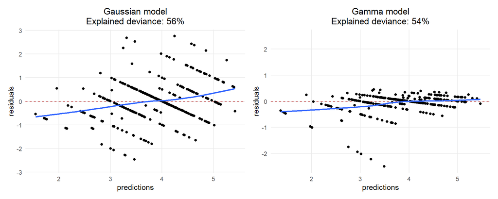

```r
# estimate models
m_st <- estimate_model(dat_model, y = "stool_type")
# m_st2 <- estimate_model(dat_model, y = "stool_type", transformation = log)
m_st3 <- estimate_model(dat_model, y = "stool_type", family = Gamma(link = "log"))


# plot residuals
plot_residuals(m_st, title = paste0("Gaussian model\nExplained deviance: ", 100*round(summary(m_st)$dev.expl, 2), "%")) +
  plot_residuals(m_st3, title = paste0("Gamma model\nExplained deviance: ", 100*round(summary(m_st3)$dev.expl, 2), "%"))
```

```r
# print intervention effects of final model
summary(m_st)$p.table %>%
  as.data.frame() %>%
  filter(grepl("intervention", row.names(.))) %>%
  dplyr::rename(estimate = "Estimate",
                sd_error = "Std. Error",
                tvalue   = "t value",
                pvalue   = "Pr(>|t|)") %>%
  mutate(CIlower  = estimate - qnorm(0.975)*sd_error,
         CIupper  = estimate + qnorm(0.975)*sd_error,
         estimate = round(estimate, 2),
         CIlower  = round(CIlower, 2),
         CIupper  = round(CIupper, 2),
         pvalue   = round(pvalue, 4)) %>%
  select(estimate, CIlower, CIupper, pvalue) %>%
  kable() %>%
  kable_styling()
```

|  | estimate | CIlower | CIupper | pvalue |
| --- | --- | --- | --- | --- |
| interventionFresh | 0.02 | -0.22 | 0.26 | 0.8601 |
| interventionPasteurized | 0.17 | -0.07 | 0.41 | 0.1605 |

##### Diversity-stratified model

Intervention effects for low diversity:

```r
# estimate model
m_st_divInt <- estimate_model(dat_model, y = "stool_type", interaction_string = "intervention:baselineDiv_cat")

# print intervention effects for low diversity people
summary(m_st_divInt)$p.table %>%
  as.data.frame() %>%
  filter(grepl("intervention", row.names(.)),
         !grepl("baselineDiv", row.names(.))) %>%
  dplyr::rename(estimate = "Estimate",
                sd_error = "Std. Error",
                tvalue   = "t value",
                pvalue   = "Pr(>|t|)") %>%
  mutate(CIlower  = estimate - qnorm(0.975)*sd_error,
         CIupper  = estimate + qnorm(0.975)*sd_error,
         estimate = round(estimate, 2),
         CIlower  = round(CIlower, 2),
         CIupper  = round(CIupper, 2),
         pvalue   = round(pvalue, 4)) %>%
  select(estimate, CIlower, CIupper, pvalue) %>%
  kable() %>%
  kable_styling()
```

|  | estimate | CIlower | CIupper | pvalue |
| --- | --- | --- | --- | --- |
| interventionFresh | 0.14 | -0.20 | 0.47 | 0.4303 |
| interventionPasteurized | 0.11 | -0.23 | 0.45 | 0.5266 |

Intervention effects for high diversity:

```r
# estimate model
m_st_divInt_changedRef <- dat_model %>%
  mutate(baselineDiv_cat = relevel(baselineDiv_cat, ref = "[3.85, 4.4)")) %>%
  estimate_model(dat = ., y = "stool_type", interaction_string = "intervention:baselineDiv_cat")

# print intervention effects for females
summary(m_st_divInt_changedRef)$p.table %>%
  as.data.frame() %>%
  filter(grepl("intervention", row.names(.)),
         !grepl("baselineDiv", row.names(.))) %>%
  dplyr::rename(estimate = "Estimate",
                sd_error = "Std. Error",
                tvalue   = "t value",
                pvalue   = "Pr(>|t|)") %>%
  mutate(CIlower  = estimate - qnorm(0.975)*sd_error,
         CIupper  = estimate + qnorm(0.975)*sd_error,
         estimate = round(estimate, 2),
         CIlower  = round(CIlower, 2),
         CIupper  = round(CIupper, 2),
         pvalue   = round(pvalue, 4)) %>%
  select(estimate, CIlower, CIupper, pvalue) %>%
  kable() %>%
  kable_styling()
```

|  | estimate | CIlower | CIupper | pvalue |
| --- | --- | --- | --- | --- |
| interventionFresh | -0.09 | -0.43 | 0.24 | 0.5938 |
| interventionPasteurized | 0.23 | -0.11 | 0.56 | 0.1826 |

##### Gender-stratified model

Intervention effects for males:

```r
# estimate model
m_st_sexInt <- estimate_model(dat_model, y = "stool_type", interaction_string = "intervention:gender")

# print intervention effects for males
summary(m_st_sexInt)$p.table %>%
  as.data.frame() %>%
  filter(grepl("intervention", row.names(.)),
         !grepl("gender", row.names(.))) %>%
  dplyr::rename(estimate = "Estimate",
                sd_error = "Std. Error",
                tvalue   = "t value",
                pvalue   = "Pr(>|t|)") %>%
  mutate(CIlower  = estimate - qnorm(0.975)*sd_error,
         CIupper  = estimate + qnorm(0.975)*sd_error,
         estimate = round(estimate, 2),
         CIlower  = round(CIlower, 2),
         CIupper  = round(CIupper, 2),
         pvalue   = round(pvalue, 4)) %>%
  select(estimate, CIlower, CIupper, pvalue) %>%
  kable() %>%
  kable_styling()
```

|  | estimate | CIlower | CIupper | pvalue |
| --- | --- | --- | --- | --- |
| interventionFresh | 0.25 | -0.11 | 0.60 | 0.1741 |
| interventionPasteurized | 0.13 | -0.22 | 0.49 | 0.4695 |

Intervention effects for females:

```r
# estimate model
m_st_sexInt_changedRef <- dat_model %>%
  mutate(gender = relevel(gender, ref = "W")) %>%
  estimate_model(dat = ., y = "stool_type", interaction_string = "intervention:gender")

# print intervention effects for females
summary(m_st_sexInt_changedRef)$p.table %>%
  as.data.frame() %>%
  filter(grepl("intervention", row.names(.)),
         !grepl("gender", row.names(.))) %>%
  dplyr::rename(estimate = "Estimate",
                sd_error = "Std. Error",
                tvalue   = "t value",
                pvalue   = "Pr(>|t|)") %>%
  mutate(CIlower  = estimate - qnorm(0.975)*sd_error,
         CIupper  = estimate + qnorm(0.975)*sd_error,
         estimate = round(estimate, 2),
         CIlower  = round(CIlower, 2),
         CIupper  = round(CIupper, 2),
         pvalue   = round(pvalue, 4)) %>%
  select(estimate, CIlower, CIupper, pvalue) %>%
  kable() %>%
  kable_styling()
```

|  | estimate | CIlower | CIupper | pvalue |
| --- | --- | --- | --- | --- |
| interventionFresh | -0.16 | -0.47 | 0.16 | 0.3296 |
| interventionPasteurized | 0.20 | -0.12 | 0.52 | 0.2154 |

##### Age-stratified model

Intervention effects for younger people:

```r
# estimate model
m_st_ageInt <- estimate_model(dat_model, y = "stool_type", interaction_string = "intervention:age_cat")

# print intervention effects for younger people
summary(m_st_ageInt)$p.table %>%
  as.data.frame() %>%
  filter(grepl("intervention", row.names(.)),
         !grepl("age_cat", row.names(.))) %>%
  dplyr::rename(estimate = "Estimate",
                sd_error = "Std. Error",
                tvalue   = "t value",
                pvalue   = "Pr(>|t|)") %>%
  mutate(CIlower  = estimate - qnorm(0.975)*sd_error,
         CIupper  = estimate + qnorm(0.975)*sd_error,
         estimate = round(estimate, 2),
         CIlower  = round(CIlower, 2),
         CIupper  = round(CIupper, 2),
         pvalue   = round(pvalue, 4)) %>%
  select(estimate, CIlower, CIupper, pvalue) %>%
  kable() %>%
  kable_styling()
```

|  | estimate | CIlower | CIupper | pvalue |
| --- | --- | --- | --- | --- |
| interventionFresh | -0.10 | -0.42 | 0.22 | 0.5369 |
| interventionPasteurized | 0.28 | -0.04 | 0.60 | 0.0914 |

Intervention effects for older people:

```r
# estimate model
m_st_ageInt_changedRef <- dat_model %>%
  mutate(age_cat = relevel(age_cat, ref = "50-69")) %>%
  estimate_model(dat = ., y = "stool_type", interaction_string = "intervention:age_cat")

# print intervention effects for older people
summary(m_st_ageInt_changedRef)$p.table %>%
  as.data.frame() %>%
  filter(grepl("intervention", row.names(.)),
         !grepl("age_cat", row.names(.))) %>%
  dplyr::rename(estimate = "Estimate",
                sd_error = "Std. Error",
                tvalue   = "t value",
                pvalue   = "Pr(>|t|)") %>%
  mutate(CIlower  = estimate - qnorm(0.975)*sd_error,
         CIupper  = estimate + qnorm(0.975)*sd_error,
         estimate = round(estimate, 2),
         CIlower  = round(CIlower, 2),
         CIupper  = round(CIupper, 2),
         pvalue   = round(pvalue, 4)) %>%
  select(estimate, CIlower, CIupper, pvalue) %>%
  kable() %>%
  kable_styling()
```

|  | estimate | CIlower | CIupper | pvalue |
| --- | --- | --- | --- | --- |
| interventionFresh | 0.17 | -0.18 | 0.52 | 0.3497 |
| interventionPasteurized | 0.05 | -0.30 | 0.40 | 0.7948 |

##### BMI-stratified model

Intervention effects for low-BMI people:

```r
# estimate model
m_st_bmiInt <- estimate_model(dat_model, y = "stool_type", interaction_string = "intervention:bmi_cat")

# print intervention effects for low-BMI people
summary(m_st_bmiInt)$p.table %>%
  as.data.frame() %>%
  filter(grepl("intervention", row.names(.)),
         !grepl("bmi_cat", row.names(.))) %>%
  dplyr::rename(estimate = "Estimate",
                sd_error = "Std. Error",
                tvalue   = "t value",
                pvalue   = "Pr(>|t|)") %>%
  mutate(CIlower  = estimate - qnorm(0.975)*sd_error,
         CIupper  = estimate + qnorm(0.975)*sd_error,
         estimate = round(estimate, 2),
         CIlower  = round(CIlower, 2),
         CIupper  = round(CIupper, 2),
         pvalue   = round(pvalue, 4)) %>%
  select(estimate, CIlower, CIupper, pvalue) %>%
  kable() %>%
  kable_styling()
```

|  | estimate | CIlower | CIupper | pvalue |
| --- | --- | --- | --- | --- |
| interventionFresh | -0.03 | -0.32 | 0.27 | 0.8540 |
| interventionPasteurized | 0.09 | -0.21 | 0.39 | 0.5523 |

Intervention effects for high-BMI people:

```r
# estimate model
m_st_bmiInt_changedRef <- dat_model %>%
  mutate(bmi_cat = relevel(bmi_cat, ref = "[25, 31]")) %>%
  estimate_model(dat = ., y = "stool_type", interaction_string = "intervention:bmi_cat")

# print intervention effects for high-BMI people
summary(m_st_bmiInt_changedRef)$p.table %>%
  as.data.frame() %>%
  filter(grepl("intervention", row.names(.)),
         !grepl("bmi_cat", row.names(.))) %>%
  dplyr::rename(estimate = "Estimate",
                sd_error = "Std. Error",
                tvalue   = "t value",
                pvalue   = "Pr(>|t|)") %>%
  mutate(CIlower  = estimate - qnorm(0.975)*sd_error,
         CIupper  = estimate + qnorm(0.975)*sd_error,
         estimate = round(estimate, 2),
         CIlower  = round(CIlower, 2),
         CIupper  = round(CIupper, 2),
         pvalue   = round(pvalue, 4)) %>%
  select(estimate, CIlower, CIupper, pvalue) %>%
  kable() %>%
  kable_styling()
```

|  | estimate | CIlower | CIupper | pvalue |
| --- | --- | --- | --- | --- |
| interventionFresh | 0.11 | -0.29 | 0.51 | 0.5912 |
| interventionPasteurized | 0.30 | -0.09 | 0.69 | 0.1297 |

##### fiber-stratified model

Intervention effects for low-fiber people:

```r
# estimate model
m_st_fibInt <- estimate_model(dat_model, y = "stool_type", interaction_string = "intervention:dailyFiber_cat")

# print intervention effects for low-fiber people
summary(m_st_fibInt)$p.table %>%
  as.data.frame() %>%
  filter(grepl("intervention", row.names(.)),
         !grepl("dailyFiber_cat", row.names(.))) %>%
  dplyr::rename(estimate = "Estimate",
                sd_error = "Std. Error",
                tvalue   = "t value",
                pvalue   = "Pr(>|t|)") %>%
  mutate(CIlower  = estimate - qnorm(0.975)*sd_error,
         CIupper  = estimate + qnorm(0.975)*sd_error,
         estimate = round(estimate, 2),
         CIlower  = round(CIlower, 2),
         CIupper  = round(CIupper, 2),
         pvalue   = round(pvalue, 4)) %>%
  select(estimate, CIlower, CIupper, pvalue) %>%
  kable() %>%
  kable_styling()
```

|  | estimate | CIlower | CIupper | pvalue |
| --- | --- | --- | --- | --- |
| interventionFresh | 0.01 | -0.25 | 0.28 | 0.9184 |
| interventionPasteurized | 0.14 | -0.12 | 0.40 | 0.2985 |

Intervention effects for high-fiber people:

```r
# estimate model
m_st_fibInt_changedRef <- dat_model %>%
  mutate(dailyFiber_cat = relevel(dailyFiber_cat, ref = ">= 30g")) %>%
  estimate_model(dat = ., y = "stool_type", interaction_string = "intervention:dailyFiber_cat")

# print intervention effects for high-fiber people
summary(m_st_fibInt_changedRef)$p.table %>%
  as.data.frame() %>%
  filter(grepl("intervention", row.names(.)),
         !grepl("dailyFiber_cat", row.names(.))) %>%
  dplyr::rename(estimate = "Estimate",
                sd_error = "Std. Error",
                tvalue   = "t value",
                pvalue   = "Pr(>|t|)") %>%
  mutate(CIlower  = estimate - qnorm(0.975)*sd_error,
         CIupper  = estimate + qnorm(0.975)*sd_error,
         estimate = round(estimate, 2),
         CIlower  = round(CIlower, 2),
         CIupper  = round(CIupper, 2),
         pvalue   = round(pvalue, 4)) %>%
  select(estimate, CIlower, CIupper, pvalue) %>%
  kable() %>%
  kable_styling()
```

|  | estimate | CIlower | CIupper | pvalue |
| --- | --- | --- | --- | --- |
| interventionFresh | 0.06 | -0.50 | 0.62 | 0.8436 |
| interventionPasteurized | 0.31 | -0.25 | 0.87 | 0.2793 |

## Models on PH value

##### Overall model

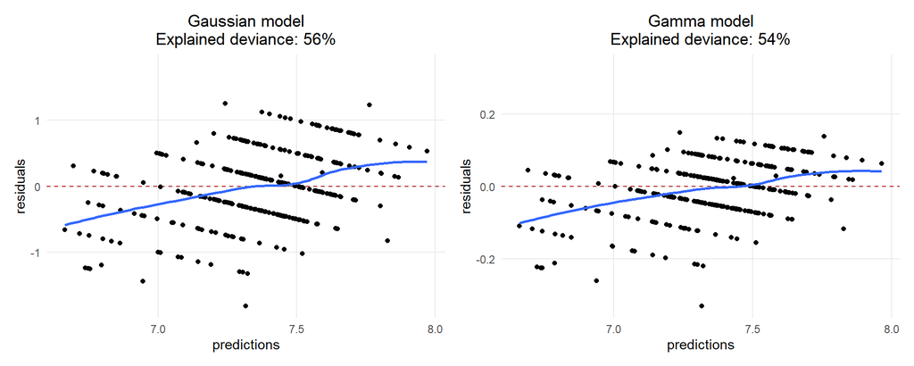

```r
# estimate models
m_ph <- estimate_model(dat_model, y = "ph_value")
m_ph2 <- estimate_model(dat_model, y = "ph_value", family = Gamma(link = "log"))


# plot residuals
plot_residuals(m_ph, title = paste0("Gaussian model\nExplained deviance: ", 100*round(summary(m_st)$dev.expl, 2), "%")) +
  plot_residuals(m_ph2, title = paste0("Gamma model\nExplained deviance: ", 100*round(summary(m_st3)$dev.expl, 2), "%"))
```

```r
# print intervention effects of final model
summary(m_ph)$p.table %>%
  as.data.frame() %>%
  filter(grepl("intervention", row.names(.))) %>%
  dplyr::rename(estimate = "Estimate",
                sd_error = "Std. Error",
                tvalue   = "t value",
                pvalue   = "Pr(>|t|)") %>%
  mutate(CIlower  = estimate - qnorm(0.975)*sd_error,
         CIupper  = estimate + qnorm(0.975)*sd_error,
         estimate = round(estimate, 2),
         CIlower  = round(CIlower, 2),
         CIupper  = round(CIupper, 2),
         pvalue   = round(pvalue, 4)) %>%
  select(estimate, CIlower, CIupper, pvalue) %>%
  kable() %>%
  kable_styling()
```

|  | estimate | CIlower | CIupper | pvalue |
| --- | --- | --- | --- | --- |
| interventionFresh | 0.06 | -0.10 | 0.22 | 0.4317 |
| interventionPasteurized | -0.05 | -0.21 | 0.11 | 0.5158 |

##### diversity-stratified model

Intervention effects for low diversity:

```r
# estimate model
m_ph_divInt <- estimate_model(dat_model, y = "ph_value", interaction_string = "intervention:baselineDiv_cat")

# print intervention effects for low diversity people
summary(m_ph_divInt)$p.table %>%
  as.data.frame() %>%
  filter(grepl("intervention", row.names(.)),
         !grepl("baselineDiv_cat", row.names(.))) %>%
  dplyr::rename(estimate = "Estimate",
                sd_error = "Std. Error",
                tvalue   = "t value",
                pvalue   = "Pr(>|t|)") %>%
  mutate(CIlower  = estimate - qnorm(0.975)*sd_error,
         CIupper  = estimate + qnorm(0.975)*sd_error,
         estimate = round(estimate, 2),
         CIlower  = round(CIlower, 2),
         CIupper  = round(CIupper, 2),
         pvalue   = round(pvalue, 4)) %>%
  select(estimate, CIlower, CIupper, pvalue) %>%
  kable() %>%
  kable_styling()
```

|  | estimate | CIlower | CIupper | pvalue |
| --- | --- | --- | --- | --- |
| interventionFresh | 0.04 | -0.20 | 0.27 | 0.7626 |
| interventionPasteurized | 0.01 | -0.23 | 0.24 | 0.9498 |

Intervention effects for high diversity:

```r
# estimate model
m_ph_divInt_changedRef <- dat_model %>%
  mutate(baselineDiv_cat = relevel(baselineDiv_cat, ref = "[3.85, 4.4)")) %>%
  estimate_model(dat = ., y = "ph_value", interaction_string = "intervention:baselineDiv_cat")

# print intervention effects for high diversity people
summary(m_ph_divInt_changedRef)$p.table %>%
  as.data.frame() %>%
  filter(grepl("intervention", row.names(.)),
         !grepl("baselineDiv_cat", row.names(.))) %>%
  dplyr::rename(estimate = "Estimate",
                sd_error = "Std. Error",
                tvalue   = "t value",
                pvalue   = "Pr(>|t|)") %>%
  mutate(CIlower  = estimate - qnorm(0.975)*sd_error,
         CIupper  = estimate + qnorm(0.975)*sd_error,
         estimate = round(estimate, 2),
         CIlower  = round(CIlower, 2),
         CIupper  = round(CIupper, 2),
         pvalue   = round(pvalue, 4)) %>%
  select(estimate, CIlower, CIupper, pvalue) %>%
  kable() %>%
  kable_styling()
```

|  | estimate | CIlower | CIupper | pvalue |
| --- | --- | --- | --- | --- |
| interventionFresh | 0.09 | -0.13 | 0.31 | 0.4249 |
| interventionPasteurized | -0.11 | -0.33 | 0.12 | 0.3517 |

##### Gender-stratified model

Intervention effects for males:

```r
# estimate model
m_ph_sexInt <- estimate_model(dat_model, y = "ph_value", interaction_string = "intervention:gender")

# print intervention effects for males
summary(m_ph_sexInt)$p.table %>%
  as.data.frame() %>%
  filter(grepl("intervention", row.names(.)),
         !grepl("gender", row.names(.))) %>%
  dplyr::rename(estimate = "Estimate",
                sd_error = "Std. Error",
                tvalue   = "t value",
                pvalue   = "Pr(>|t|)") %>%
  mutate(CIlower  = estimate - qnorm(0.975)*sd_error,
         CIupper  = estimate + qnorm(0.975)*sd_error,
         estimate = round(estimate, 2),
         CIlower  = round(CIlower, 2),
         CIupper  = round(CIupper, 2),
         pvalue   = round(pvalue, 4)) %>%
  select(estimate, CIlower, CIupper, pvalue) %>%
  kable() %>%
  kable_styling()
```

|  | estimate | CIlower | CIupper | pvalue |
| --- | --- | --- | --- | --- |
| interventionFresh | 0.18 | -0.06 | 0.42 | 0.1421 |
| interventionPasteurized | 0.04 | -0.20 | 0.28 | 0.7431 |

Intervention effects for females:

```r
# estimate model
m_ph_sexInt_changedRef <- dat_model %>%
  mutate(gender = relevel(gender, ref = "W")) %>%
  estimate_model(dat = ., y = "ph_value", interaction_string = "intervention:gender")

# print intervention effects for females
summary(m_ph_sexInt_changedRef)$p.table %>%
  as.data.frame() %>%
  filter(grepl("intervention", row.names(.)),
         !grepl("gender", row.names(.))) %>%
  dplyr::rename(estimate = "Estimate",
                sd_error = "Std. Error",
                tvalue   = "t value",
                pvalue   = "Pr(>|t|)") %>%
  mutate(CIlower  = estimate - qnorm(0.975)*sd_error,
         CIupper  = estimate + qnorm(0.975)*sd_error,
         estimate = round(estimate, 2),
         CIlower  = round(CIlower, 2),
         CIupper  = round(CIupper, 2),
         pvalue   = round(pvalue, 4)) %>%
  select(estimate, CIlower, CIupper, pvalue) %>%
  kable() %>%
  kable_styling()
```

|  | estimate | CIlower | CIupper | pvalue |
| --- | --- | --- | --- | --- |
| interventionFresh | -0.03 | -0.24 | 0.19 | 0.7946 |
| interventionPasteurized | -0.13 | -0.35 | 0.09 | 0.2443 |

##### Age-stratified model

Intervention effects for younger people:

```r
# estimate model
m_ph_ageInt <- estimate_model(dat_model, y = "ph_value", interaction_string = "intervention:age_cat")

# print intervention effects for younger people
summary(m_ph_ageInt)$p.table %>%
  as.data.frame() %>%
  filter(grepl("intervention", row.names(.)),
         !grepl("age_cat", row.names(.))) %>%
  dplyr::rename(estimate = "Estimate",
                sd_error = "Std. Error",
                tvalue   = "t value",
                pvalue   = "Pr(>|t|)") %>%
  mutate(CIlower  = estimate - qnorm(0.975)*sd_error,
         CIupper  = estimate + qnorm(0.975)*sd_error,
         estimate = round(estimate, 2),
         CIlower  = round(CIlower, 2),
         CIupper  = round(CIupper, 2),
         pvalue   = round(pvalue, 4)) %>%
  select(estimate, CIlower, CIupper, pvalue) %>%
  kable() %>%
  kable_styling()
```

|  | estimate | CIlower | CIupper | pvalue |
| --- | --- | --- | --- | --- |
| interventionFresh | 0.11 | -0.11 | 0.33 | 0.3163 |
| interventionPasteurized | -0.01 | -0.23 | 0.20 | 0.9082 |

Intervention effects for older people:

```r
# estimate model
m_ph_ageInt_changedRef <- dat_model %>%
  mutate(age_cat = relevel(age_cat, ref = "50-69")) %>%
  estimate_model(dat = ., y = "ph_value", interaction_string = "intervention:age_cat")

# print intervention effects for older people
summary(m_ph_ageInt_changedRef)$p.table %>%
  as.data.frame() %>%
  filter(grepl("intervention", row.names(.)),
         !grepl("age_cat", row.names(.))) %>%
  dplyr::rename(estimate = "Estimate",
                sd_error = "Std. Error",
                tvalue   = "t value",
                pvalue   = "Pr(>|t|)") %>%
  mutate(CIlower  = estimate - qnorm(0.975)*sd_error,
         CIupper  = estimate + qnorm(0.975)*sd_error,
         estimate = round(estimate, 2),
         CIlower  = round(CIlower, 2),
         CIupper  = round(CIupper, 2),
         pvalue   = round(pvalue, 4)) %>%
  select(estimate, CIlower, CIupper, pvalue) %>%
  kable() %>%
  kable_styling()
```

|  | estimate | CIlower | CIupper | pvalue |
| --- | --- | --- | --- | --- |
| interventionFresh | 0.01 | -0.23 | 0.25 | 0.9491 |
| interventionPasteurized | -0.10 | -0.35 | 0.14 | 0.4005 |

##### BMI-stratified model

Intervention effects for low-BMI people:

```r
# estimate model
m_ph_bmiInt <- estimate_model(dat_model, y = "ph_value", interaction_string = "intervention:bmi_cat")

# print intervention effects for low-BMI people
summary(m_ph_bmiInt)$p.table %>%
  as.data.frame() %>%
  filter(grepl("intervention", row.names(.)),
         !grepl("bmi_cat", row.names(.))) %>%
  dplyr::rename(estimate = "Estimate",
                sd_error = "Std. Error",
                tvalue   = "t value",
                pvalue   = "Pr(>|t|)") %>%
  mutate(CIlower  = estimate - qnorm(0.975)*sd_error,
         CIupper  = estimate + qnorm(0.975)*sd_error,
         estimate = round(estimate, 2),
         CIlower  = round(CIlower, 2),
         CIupper  = round(CIupper, 2),
         pvalue   = round(pvalue, 4)) %>%
  select(estimate, CIlower, CIupper, pvalue) %>%
  kable() %>%
  kable_styling()
```

|  | estimate | CIlower | CIupper | pvalue |
| --- | --- | --- | --- | --- |
| interventionFresh | 0.13 | -0.07 | 0.33 | 0.2047 |
| interventionPasteurized | -0.09 | -0.29 | 0.11 | 0.3932 |

Intervention effects for high-BMI people:

```r
# estimate model
m_ph_bmiInt_changedRef <- dat_model %>%
  mutate(bmi_cat = relevel(bmi_cat, ref = "[25, 31]")) %>%
  estimate_model(dat = ., y = "ph_value", interaction_string = "intervention:bmi_cat")

# print intervention effects for high-BMI people
summary(m_ph_bmiInt_changedRef)$p.table %>%
  as.data.frame() %>%
  filter(grepl("intervention", row.names(.)),
         !grepl("bmi_cat", row.names(.))) %>%
  dplyr::rename(estimate = "Estimate",
                sd_error = "Std. Error",
                tvalue   = "t value",
                pvalue   = "Pr(>|t|)") %>%
  mutate(CIlower  = estimate - qnorm(0.975)*sd_error,
         CIupper  = estimate + qnorm(0.975)*sd_error,
         estimate = round(estimate, 2),
         CIlower  = round(CIlower, 2),
         CIupper  = round(CIupper, 2),
         pvalue   = round(pvalue, 4)) %>%
  select(estimate, CIlower, CIupper, pvalue) %>%
  kable() %>%
  kable_styling()
```

|  | estimate | CIlower | CIupper | pvalue |
| --- | --- | --- | --- | --- |
| interventionFresh | -0.06 | -0.33 | 0.21 | 0.6627 |
| interventionPasteurized | 0.01 | -0.25 | 0.28 | 0.9281 |

##### fiber-stratified model

Intervention effects for low-fiber people:

```r
# estimate model
m_ph_fibInt <- estimate_model(dat_model, y = "ph_value", interaction_string = "intervention:dailyFiber_cat")

# print intervention effects for low-fiber people
summary(m_ph_fibInt)$p.table %>%
  as.data.frame() %>%
  filter(grepl("intervention", row.names(.)),
         !grepl("dailyFiber_cat", row.names(.))) %>%
  dplyr::rename(estimate = "Estimate",
                sd_error = "Std. Error",
                tvalue   = "t value",
                pvalue   = "Pr(>|t|)") %>%
  mutate(CIlower  = estimate - qnorm(0.975)*sd_error,
         CIupper  = estimate + qnorm(0.975)*sd_error,
         estimate = round(estimate, 2),
         CIlower  = round(CIlower, 2),
         CIupper  = round(CIupper, 2),
         pvalue   = round(pvalue, 4)) %>%
  select(estimate, CIlower, CIupper, pvalue) %>%
  kable() %>%
  kable_styling()
```

|  | estimate | CIlower | CIupper | pvalue |
| --- | --- | --- | --- | --- |
| interventionFresh | 0.05 | -0.12 | 0.23 | 0.5493 |
| interventionPasteurized | -0.08 | -0.26 | 0.10 | 0.3658 |

Intervention effects for high-fiber people:

```r
# estimate model
m_ph_fibInt_changedRef <- dat_model %>%
  mutate(dailyFiber_cat = relevel(dailyFiber_cat, ref = ">= 30g")) %>%
  estimate_model(dat = ., y = "ph_value", interaction_string = "intervention:dailyFiber_cat")

# print intervention effects for high-fiber people
summary(m_ph_fibInt_changedRef)$p.table %>%
  as.data.frame() %>%
  filter(grepl("intervention", row.names(.)),
         !grepl("dailyFiber_cat", row.names(.))) %>%
  dplyr::rename(estimate = "Estimate",
                sd_error = "Std. Error",
                tvalue   = "t value",
                pvalue   = "Pr(>|t|)") %>%
  mutate(CIlower  = estimate - qnorm(0.975)*sd_error,
         CIupper  = estimate + qnorm(0.975)*sd_error,
         estimate = round(estimate, 2),
         CIlower  = round(CIlower, 2),
         CIupper  = round(CIupper, 2),
         pvalue   = round(pvalue, 4)) %>%
  select(estimate, CIlower, CIupper, pvalue) %>%
  kable() %>%
  kable_styling()
```

|  | estimate | CIlower | CIupper | pvalue |
| --- | --- | --- | --- | --- |
| interventionFresh | 0.11 | -0.28 | 0.51 | 0.5769 |
| interventionPasteurized | 0.08 | -0.30 | 0.46 | 0.6842 |

## Models on bowel movement frequency

Analyze the logistic question whether bowel movement frequency is ‘once daily or more often’ vs. ‘more rarely than once daily’. Positive effects in the following models encode a higher chance to have frequency ‘once daily or more often’.

```r
dat_model <- dat_model %>%
  mutate(bowelMovement_freq_binary = case_when(is.na(bowelMovement_freq)             ~ NA_character_,
                                               grepl("taeglich", bowelMovement_freq) ~ "once daily or more often",
                                               TRUE                                  ~ "more rarely than once daily"),
         bowelMovement_freq_binary = factor(bowelMovement_freq_binary,
                                            levels = c("more rarely than once daily", "once daily or more often")))
```

##### Overall model

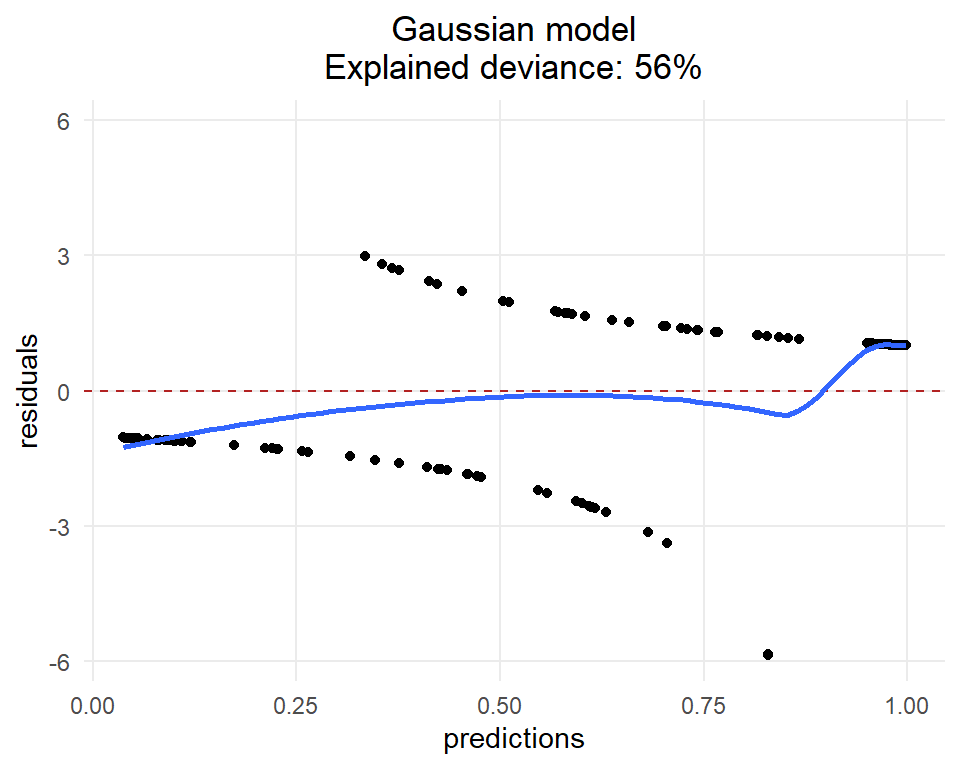

```r
# estimate models
m_bm <- estimate_model(dat_model, y = "bowelMovement_freq_binary", family = binomial(link = "logit"))


# plot residuals
plot_residuals(m_bm, title = paste0("Gaussian model\nExplained deviance: ", 100*round(summary(m_st)$dev.expl, 2), "%"))
```

```r
# print intervention effects of final model
summary(m_bm)$p.table %>%
  as.data.frame() %>%
  filter(grepl("intervention", row.names(.))) %>%
  dplyr::rename(estimate = "Estimate",
                sd_error = "Std. Error",
                zvalue   = "z value",
                pvalue   = "Pr(>|z|)") %>%
  mutate(CIlower      = estimate - qnorm(0.975)*sd_error,
         CIupper      = estimate + qnorm(0.975)*sd_error,
         exp_estimate = exp(estimate),
         exp_CIlower  = exp(CIlower),
         exp_CIupper  = exp(CIupper),
         exp_estimate = round(exp_estimate, 2),
         exp_CIlower  = round(exp_CIlower, 2),
         exp_CIupper  = round(exp_CIupper, 2),
         pvalue       = round(pvalue, 4)) %>%
  select(exp_estimate, exp_CIlower, exp_CIupper, pvalue) %>%
  kable() %>%
  kable_styling()
```

|  | exp_estimate | exp_CIlower | exp_CIupper | pvalue |
| --- | --- | --- | --- | --- |
| interventionFresh | 0.92 | 0.31 | 2.74 | 0.8754 |
| interventionPasteurized | 1.22 | 0.40 | 3.76 | 0.7276 |

##### diversity-stratified model

Intervention effects for low diversity:

```r
# estimate model
m_bm_divInt <- estimate_model(dat_model, y = "bowelMovement_freq_binary", family = binomial(link = "logit"), interaction_string = "intervention:baselineDiv_cat")

# print intervention effects for males
summary(m_bm_divInt)$p.table %>%
  as.data.frame() %>%
  filter(grepl("intervention", row.names(.)),
         !grepl("baselineDiv_cat", row.names(.))) %>%
  dplyr::rename(estimate = "Estimate",
                sd_error = "Std. Error",
                zvalue   = "z value",
                pvalue   = "Pr(>|z|)") %>%
  mutate(CIlower      = estimate - qnorm(0.975)*sd_error,
         CIupper      = estimate + qnorm(0.975)*sd_error,
         exp_estimate = exp(estimate),
         exp_CIlower  = exp(CIlower),
         exp_CIupper  = exp(CIupper),
         exp_estimate = round(exp_estimate, 2),
         exp_CIlower  = round(exp_CIlower, 2),
         exp_CIupper  = round(exp_CIupper, 2),
         pvalue       = round(pvalue, 4)) %>%
  select(exp_estimate, exp_CIlower, exp_CIupper, pvalue) %>%
  kable() %>%
  kable_styling()
```

|  | exp_estimate | exp_CIlower | exp_CIupper | pvalue |
| --- | --- | --- | --- | --- |
| interventionFresh | 0.62 | 0.10 | 3.94 | 0.6092 |
| interventionPasteurized | 0.39 | 0.05 | 2.99 | 0.3672 |

Intervention effects for high diversity:

```r
# estimate model
m_bm_divInt_changedRef <- dat_model %>%
  mutate(baselineDiv_cat = relevel(baselineDiv_cat, ref = "[3.85, 4.4)")) %>%
  estimate_model(dat = ., y = "bowelMovement_freq_binary", family = binomial(link = "logit"), interaction_string = "intervention:baselineDiv_cat")

# print intervention effects for high diversity
summary(m_bm_divInt_changedRef)$p.table %>%
  as.data.frame() %>%
  filter(grepl("intervention", row.names(.)),
         !grepl("baselineDiv_cat", row.names(.))) %>%
  dplyr::rename(estimate = "Estimate",
                sd_error = "Std. Error",
                zvalue   = "z value",
                pvalue   = "Pr(>|z|)") %>%
  mutate(CIlower      = estimate - qnorm(0.975)*sd_error,
         CIupper      = estimate + qnorm(0.975)*sd_error,
         exp_estimate = exp(estimate),
         exp_CIlower  = exp(CIlower),
         exp_CIupper  = exp(CIupper),
         exp_estimate = round(exp_estimate, 2),
         exp_CIlower  = round(exp_CIlower, 2),
         exp_CIupper  = round(exp_CIupper, 2),
         pvalue       = round(pvalue, 4)) %>%
  select(exp_estimate, exp_CIlower, exp_CIupper, pvalue) %>%
  kable() %>%
  kable_styling()
```

|  | exp_estimate | exp_CIlower | exp_CIupper | pvalue |
| --- | --- | --- | --- | --- |
| interventionFresh | 1.10 | 0.26 | 4.55 | 0.8985 |
| interventionPasteurized | 2.27 | 0.52 | 10.00 | 0.2764 |

##### Gender-stratified model

Intervention effects for males:

```r
# estimate model
m_bm_sexInt <- estimate_model(dat_model, y = "bowelMovement_freq_binary", family = binomial(link = "logit"), interaction_string = "intervention:gender")

# print intervention effects for males
summary(m_bm_sexInt)$p.table %>%
  as.data.frame() %>%
  filter(grepl("intervention", row.names(.)),
         !grepl("gender", row.names(.))) %>%
  dplyr::rename(estimate = "Estimate",
                sd_error = "Std. Error",
                zvalue   = "z value",
                pvalue   = "Pr(>|z|)") %>%
  mutate(CIlower      = estimate - qnorm(0.975)*sd_error,
         CIupper      = estimate + qnorm(0.975)*sd_error,
         exp_estimate = exp(estimate),
         exp_CIlower  = exp(CIlower),
         exp_CIupper  = exp(CIupper),
         exp_estimate = round(exp_estimate, 2),
         exp_CIlower  = round(exp_CIlower, 2),
         exp_CIupper  = round(exp_CIupper, 2),
         pvalue       = round(pvalue, 4)) %>%
  select(exp_estimate, exp_CIlower, exp_CIupper, pvalue) %>%
  kable() %>%
  kable_styling()
```

|  | exp_estimate | exp_CIlower | exp_CIupper | pvalue |
| --- | --- | --- | --- | --- |
| interventionFresh | 0.35 | 0.04 | 2.80 | 0.3252 |
| interventionPasteurized | 5.50 | 0.29 | 103.99 | 0.2558 |

Intervention effects for females:

```r
# estimate model
m_bm_sexInt_changedRef <- dat_model %>%
  mutate(gender = relevel(gender, ref = "W")) %>%
  estimate_model(dat = ., y = "bowelMovement_freq_binary", family = binomial(link = "logit"), interaction_string = "intervention:gender")

# print intervention effects for females
summary(m_bm_sexInt_changedRef)$p.table %>%
  as.data.frame() %>%
  filter(grepl("intervention", row.names(.)),
         !grepl("gender", row.names(.))) %>%
  dplyr::rename(estimate = "Estimate",
                sd_error = "Std. Error",
                zvalue   = "z value",
                pvalue   = "Pr(>|z|)") %>%
  mutate(CIlower      = estimate - qnorm(0.975)*sd_error,
         CIupper      = estimate + qnorm(0.975)*sd_error,
         exp_estimate = exp(estimate),
         exp_CIlower  = exp(CIlower),
         exp_CIupper  = exp(CIupper),
         exp_estimate = round(exp_estimate, 2),
         exp_CIlower  = round(exp_CIlower, 2),
         exp_CIupper  = round(exp_CIupper, 2),
         pvalue       = round(pvalue, 4)) %>%
  select(exp_estimate, exp_CIlower, exp_CIupper, pvalue) %>%
  kable() %>%
  kable_styling()
```

|  | exp_estimate | exp_CIlower | exp_CIupper | pvalue |
| --- | --- | --- | --- | --- |
| interventionFresh | 1.39 | 0.36 | 5.35 | 0.6328 |
| interventionPasteurized | 0.91 | 0.25 | 3.32 | 0.8823 |

##### Age-stratified model

Intervention effects for younger people:

```r
# estimate model
m_bm_ageInt <- estimate_model(dat_model, y = "bowelMovement_freq_binary", family = binomial(link = "logit"), interaction_string = "intervention:age_cat")

# print intervention effects for younger people
summary(m_bm_ageInt)$p.table %>%
  as.data.frame() %>%
  filter(grepl("intervention", row.names(.)),
         !grepl("age_cat", row.names(.))) %>%
  dplyr::rename(estimate = "Estimate",
                sd_error = "Std. Error",
                zvalue   = "z value",
                pvalue   = "Pr(>|z|)") %>%
  mutate(CIlower      = estimate - qnorm(0.975)*sd_error,
         CIupper      = estimate + qnorm(0.975)*sd_error,
         exp_estimate = exp(estimate),
         exp_CIlower  = exp(CIlower),
         exp_CIupper  = exp(CIupper),
         exp_estimate = round(exp_estimate, 2),
         exp_CIlower  = round(exp_CIlower, 2),
         exp_CIupper  = round(exp_CIupper, 2),
         pvalue       = round(pvalue, 4)) %>%
  select(exp_estimate, exp_CIlower, exp_CIupper, pvalue) %>%
  kable() %>%
  kable_styling()
```

|  | exp_estimate | exp_CIlower | exp_CIupper | pvalue |
| --- | --- | --- | --- | --- |
| interventionFresh | 0.81 | 0.18 | 3.60 | 0.7768 |
| interventionPasteurized | 1.12 | 0.24 | 5.33 | 0.8869 |

Intervention effects for older people:

```r
# estimate model
m_bm_ageInt_changedRef <- dat_model %>%
  mutate(age_cat = relevel(age_cat, ref = "50-69")) %>%
  estimate_model(dat = ., y = "bowelMovement_freq_binary", family = binomial(link = "logit"), interaction_string = "intervention:age_cat")

# print intervention effects for older people
summary(m_bm_ageInt_changedRef)$p.table %>%
  as.data.frame() %>%
  filter(grepl("intervention", row.names(.)),
         !grepl("age_cat", row.names(.))) %>%
  dplyr::rename(estimate = "Estimate",
                sd_error = "Std. Error",
                zvalue   = "z value",
                pvalue   = "Pr(>|z|)") %>%
  mutate(CIlower      = estimate - qnorm(0.975)*sd_error,
         CIupper      = estimate + qnorm(0.975)*sd_error,
         exp_estimate = exp(estimate),
         exp_CIlower  = exp(CIlower),
         exp_CIupper  = exp(CIupper),
         exp_estimate = round(exp_estimate, 2),
         exp_CIlower  = round(exp_CIlower, 2),
         exp_CIupper  = round(exp_CIupper, 2),
         pvalue       = round(pvalue, 4)) %>%
  select(exp_estimate, exp_CIlower, exp_CIupper, pvalue) %>%
  kable() %>%
  kable_styling()
```

|  | exp_estimate | exp_CIlower | exp_CIupper | pvalue |
| --- | --- | --- | --- | --- |
| interventionFresh | 1.07 | 0.20 | 5.62 | 0.9373 |
| interventionPasteurized | 1.39 | 0.26 | 7.40 | 0.7023 |

##### BMI-stratified model

Intervention effects for low-BMI people:

```r
# estimate model
m_bm_bmiInt <- estimate_model(dat_model, y = "bowelMovement_freq_binary", family = binomial(link = "logit"), interaction_string = "intervention:bmi_cat")

# print intervention effects for low-BMI people
summary(m_bm_bmiInt)$p.table %>%
  as.data.frame() %>%
  filter(grepl("intervention", row.names(.)),
         !grepl("bmi_cat", row.names(.))) %>%
  dplyr::rename(estimate = "Estimate",
                sd_error = "Std. Error",
                zvalue   = "z value",
                pvalue   = "Pr(>|z|)") %>%
  mutate(CIlower      = estimate - qnorm(0.975)*sd_error,
         CIupper      = estimate + qnorm(0.975)*sd_error,
         exp_estimate = exp(estimate),
         exp_CIlower  = exp(CIlower),
         exp_CIupper  = exp(CIupper),
         exp_estimate = round(exp_estimate, 2),
         exp_CIlower  = round(exp_CIlower, 2),
         exp_CIupper  = round(exp_CIupper, 2),
         pvalue       = round(pvalue, 4)) %>%
  select(exp_estimate, exp_CIlower, exp_CIupper, pvalue) %>%
  kable() %>%
  kable_styling()
```

|  | exp_estimate | exp_CIlower | exp_CIupper | pvalue |
| --- | --- | --- | --- | --- |
| interventionFresh | 0.68 | 0.14 | 3.39 | 0.6374 |
| interventionPasteurized | 0.68 | 0.13 | 3.46 | 0.6405 |

Intervention effects for high-BMI people:

```r
# estimate model
m_bm_bmiInt_changedRef <- dat_model %>%
  mutate(bmi_cat = relevel(bmi_cat, ref = "[25, 31]")) %>%
  estimate_model(dat = ., y = "bowelMovement_freq_binary", family = binomial(link = "logit"), interaction_string = "intervention:bmi_cat")

# print intervention effects for high-BMI people
summary(m_bm_bmiInt_changedRef)$p.table %>%
  as.data.frame() %>%
  filter(grepl("intervention", row.names(.)),
         !grepl("bmi_cat", row.names(.))) %>%
  dplyr::rename(estimate = "Estimate",
                sd_error = "Std. Error",
                zvalue   = "z value",
                pvalue   = "Pr(>|z|)") %>%
  mutate(CIlower      = estimate - qnorm(0.975)*sd_error,
         CIupper      = estimate + qnorm(0.975)*sd_error,
         exp_estimate = exp(estimate),
         exp_CIlower  = exp(CIlower),
         exp_CIupper  = exp(CIupper),
         exp_estimate = round(exp_estimate, 2),
         exp_CIlower  = round(exp_CIlower, 2),
         exp_CIupper  = round(exp_CIupper, 2),
         pvalue       = round(pvalue, 4)) %>%
  select(exp_estimate, exp_CIlower, exp_CIupper, pvalue) %>%
  kable() %>%
  kable_styling()
```

|  | exp_estimate | exp_CIlower | exp_CIupper | pvalue |
| --- | --- | --- | --- | --- |
| interventionFresh | 1.18 | 0.25 | 5.61 | 0.8392 |
| interventionPasteurized | 2.21 | 0.43 | 11.37 | 0.3414 |

##### fiber-stratified model

Intervention effects for low-fiber people:

```r
# estimate model
m_bm_fibInt <- estimate_model(dat_model, y = "bowelMovement_freq_binary", family = binomial(link = "logit"), interaction_string = "intervention:dailyFiber_cat")

# print intervention effects for low-fiber people
summary(m_bm_fibInt)$p.table %>%
  as.data.frame() %>%
  filter(grepl("intervention", row.names(.)),
         !grepl("dailyFiber_cat", row.names(.))) %>%
  dplyr::rename(estimate = "Estimate",
                sd_error = "Std. Error",
                zvalue   = "z value",
                pvalue   = "Pr(>|z|)") %>%
  mutate(CIlower      = estimate - qnorm(0.975)*sd_error,
         CIupper      = estimate + qnorm(0.975)*sd_error,
         exp_estimate = exp(estimate),
         exp_CIlower  = exp(CIlower),
         exp_CIupper  = exp(CIupper),
         exp_estimate = round(exp_estimate, 2),
         exp_CIlower  = round(exp_CIlower, 2),
         exp_CIupper  = round(exp_CIupper, 2),
         pvalue       = round(pvalue, 4)) %>%
  select(exp_estimate, exp_CIlower, exp_CIupper, pvalue) %>%
  kable() %>%
  kable_styling()
```

|  | exp_estimate | exp_CIlower | exp_CIupper | pvalue |
| --- | --- | --- | --- | --- |
| interventionFresh | 0.91 | 0.28 | 2.95 | 0.8687 |
| interventionPasteurized | 1.28 | 0.37 | 4.37 | 0.6960 |

Intervention effects for high-fiber people:

```r
# estimate model
m_bm_fibInt_changedRef <- dat_model %>%
  mutate(dailyFiber_cat = relevel(dailyFiber_cat, ref = ">= 30g")) %>%
  estimate_model(dat = ., y = "bowelMovement_freq_binary", family = binomial(link = "logit"), interaction_string = "intervention:dailyFiber_cat")

# print intervention effects for high-fiber people
summary(m_bm_fibInt_changedRef)$p.table %>%
  as.data.frame() %>%
  filter(grepl("intervention", row.names(.)),
         !grepl("dailyFiber_cat", row.names(.))) %>%
  dplyr::rename(estimate = "Estimate",
                sd_error = "Std. Error",
                zvalue   = "z value",
                pvalue   = "Pr(>|z|)") %>%
  mutate(CIlower      = estimate - qnorm(0.975)*sd_error,
         CIupper      = estimate + qnorm(0.975)*sd_error,
         exp_estimate = exp(estimate),
         exp_CIlower  = exp(CIlower),
         exp_CIupper  = exp(CIupper),
         exp_estimate = round(exp_estimate, 2),
         exp_CIlower  = round(exp_CIlower, 2),
         exp_CIupper  = round(exp_CIupper, 2),
         pvalue       = round(pvalue, 4)) %>%
  select(exp_estimate, exp_CIlower, exp_CIupper, pvalue) %>%
  kable() %>%
  kable_styling()
```

|  | exp_estimate | exp_CIlower | exp_CIupper | pvalue |
| --- | --- | --- | --- | --- |
| interventionFresh | 1 | 0.04 | 26.55 | 0.9988 |
| interventionPasteurized | 1 | 0.04 | 22.80 | 0.9989 |